# Math 300 NTI Lesson 27

Case Study

Professor Bradley Warner

July, 2022

## Objectives

1. Calculate, using both percentile and standard error methods, confidence intervals for a difference of two proportions.
2. Calculate a normal-based, theory-based, confidence interval for a single proportion or mean.
3. Correctly use all terms and notation to include standard error, margin of error, sampling distribution, and bootstrap distribution.
4. Compare and contrast sampling distribution and bootstrap distribution.

## Reading

[Chapter 8.6-8.7](https://moderndive.com/8-confidence-intervals.html#case-study-two-prop-ci)

## Lesson

*Remember that you will be running this more like a lab than a lecture. You want them using `R` and answering questions. Have them open the notes rmd and work through it together.*

There are no learning checks for this lesson. If you finish early, let the students work on the problem set.

- The case study brings all the ideas together while introducing a two-sample test.
- The bootstrap sample needs to be the same as the original sample. What is not clear is if they sampled such that there will be 16 in the control group and 34 in the seed group. The `infer` package does not allow us to sample within groups so we sample with replacement from the entire sample.
- Explain all the choices in the code for the bootstrap distribution and confidence interval.

### Libraries

```r
library(tidyverse)
library(moderndive)
library(infer)
```

### Yawning Problem

The reading discusses the research question “Is yawning contagious?”. Let’s summarize the data in two different ways.

```r
mythbusters_yawn %>%
  group_by(group, yawn) %>%
  summarize(count = n()) %>%
  mutate(prop = count / sum(count))
```

```
## # A tibble: 4 x 4
## # Groups:   group [2]
##   group   yawn  count  prop
##   <chr>   <chr> <int> <dbl>
## 1 control no       12 0.75
## 2 control yes       4 0.25
## 3 seed    no       24 0.706
## 4 seed    yes      10 0.294
```

- What does this summary tell the reader? This is finding proportions conditioned on groups.

**Answer:** This tells us the proportion of yawns within each group. Thus .25 is the proportion of those in the control group that did yawn.

Now another summary is as follows:

```r
mythbusters_yawn %>%
  group_by(group, yawn) %>%
  summarize(count = n()) %>%
  ungroup() %>%
  mutate(prop = count / sum(count))
```

```
## # A tibble: 4 x 4
##   group   yawn  count  prop
##   <chr>   <chr> <int> <dbl>
## 1 control no       12  0.24
## 2 control yes       4  0.08
## 3 seed    no       24  0.48
## 4 seed    yes      10  0.2
```

- What does this summary tell us about the data?

**Answer:** This gives us the proportion of the total sample that falls within the combination of the two variables. Thus 0.24 is the proportion of the sample that is in the control group and did not yawn.

- Which summary is better for the research question?

**Answer:** The first summary is more appropriate because it is comparing proportions within groups. Otherwise the size of the group would impact the proportion.

Let’s determine how the `infer` package samples the data.

```r
set.seed(77)
mythbusters_yawn %>%
  specify(formula = yawn ~ group,success="yes") %>%
  generate(reps = 1, type = "bootstrap") %>%
  group_by(group, yawn) %>%
  summarize(count = n()) %>%
  mutate(prop = count / sum(count))
```

```
## # A tibble: 4 x 4
## # Groups:   group [2]
##   group   yawn  count  prop
##   <fct>   <fct> <int> <dbl>
## 1 control no       13 0.765
## 2 control yes       4 0.235
## 3 seed    no       27 0.818
## 4 seed    yes       6 0.182
```

The numbers in the control and seed group changed. The sample is with replacement from the entire data frame and not within groups.

### Bootstrap Sampling Distribution

#### Generate the bootstrap distribution

```r
(bootstrap_distribution_yawning <- mythbusters_yawn %>%
  specify(formula = yawn ~ group, success = "yes") %>%
  generate(reps = 1000, type = "bootstrap") %>%
  calculate(stat = "diff in props", order = c("seed", "control")))
```

```
## Response: yawn (factor)
## Explanatory: group (factor)
## # A tibble: 1,000 x 2
##    replicate    stat
##        <int>   <dbl>
##  1         1 -0.154
##  2         2 -0.0900
##  3         3 -0.0303
##  4         4  0.143
##  5         5  0.0521
##  6         6  0
##  7         7  0
##  8         8 -0.0746
##  9         9 -0.0374
## 10        10  0.116
## # ... with 990 more rows
```

#### Visualize the results.

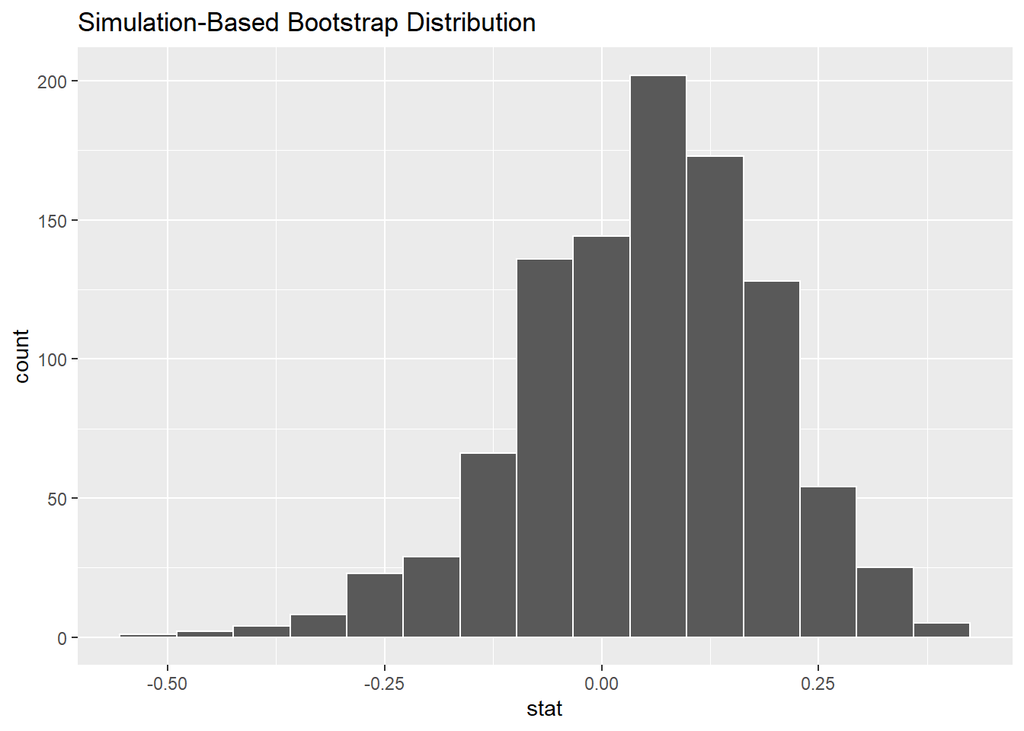

```r
visualize(bootstrap_distribution_yawning)
```

- Where is the center of this distribution?

**Answer:** It should be close to the observed value of 0.044

```r
10/34-4/16
```

```
## [1] 0.04411765
```

```r
bootstrap_distribution_yawning %>%
  summarize(ave=mean(stat))
```

```
## # A tibble: 1 x 1
##      ave
##    <dbl>
## 1 0.0503
```

#### Confidence Interval

```r
get_ci(bootstrap_distribution_yawning,type="percentile")
```

```
## # A tibble: 1 x 2
##   lower_ci upper_ci
##      <dbl>    <dbl>
## 1   -0.259    0.302
```

- Interpret this confidence interval.

**Answer:** We are 95% confidence the true difference in proportion of people yawning in seed group and control group is between -0.26 and 0.30.

### Theory-based confidence interval

For the data object `bowl_sample_1` find a 95% confidence interval using the bootstrap percentile, bootstrap standard error method, and the theory-based method.

```r
head(bowl_sample_1)
```

```
## # A tibble: 6 x 1
##   color
##   <chr>
## 1 white
## 2 white
## 3 red
## 4 red
## 5 white
## 6 white
```

- Find the bootstrap percentile confidence interval for this problem.

**Answer:**

```r
bowl_sample_1 %>%
  summarize(prop=mean(color=="red"))
```

```
## # A tibble: 1 x 1
##    prop
##   <dbl>
## 1  0.42
```

```r
set.seed(45678)
bootstrap_dist<-bowl_sample_1 %>%
  specify(color~NULL,success="red") %>%
  generate(reps=1000,type="bootstrap") %>%
  calculate(stat="prop")
```

```r
get_ci(bootstrap_dist,type="percentile")
```

```
## # A tibble: 1 x 2
##   lower_ci upper_ci
##      <dbl>    <dbl>
## 1     0.28     0.56
```

- Find the bootstrap standard error confidence interval for this problem.

**Answer:**

```r
get_ci(bootstrap_dist,type="se",point_estimate = .42)
```

```
## # A tibble: 1 x 2
##   lower_ci upper_ci
##      <dbl>    <dbl>
## 1    0.285    0.555
```

- Find the theory-based confidence interval for this problem.

**Answer:**

```r
bowl_sample_1 %>%
  summarize(prop=mean(color=="red"),total=n()) %>%
  mutate(lower_ci=prop-qnorm(.975)*sqrt(prop*(1-prop)/total),
         upper_ci=prop+qnorm(.975)*sqrt(prop*(1-prop)/total))
```

```
## # A tibble: 1 x 4
##    prop total lower_ci upper_ci
##   <dbl> <int>    <dbl>    <dbl>
## 1  0.42    50    0.283    0.557
```

## Documenting software

- File creation date: 2022-07-06
- R version 4.1.3 (2022-03-10)
- `tidyverse` package version: 1.3.1
- `moderndive` package version: 0.5.4
- `infer` package version: 1.0.2